# Introduction to data science - Ch5-Ch6

# Linear And Logistic Regression

**What is Regression?** Regression is a statistical measurement that attempts to determine the strength of the relationship between one dependent variable(Y)  
and a series of other changing variables(X). **Linear regression** shows us linear relationship between variables

Linear regression builds a model such that the predicted numerical output is a linear additive function of the inputs.

If you’re trying to predict a numerical quantity like profit, cost, or sales volume, you should always try linear regression first. **Logistic regression** is more differant from linear regression because Dependent variable in Logistic regression is discrete variable

Logistic regression always predicts a value between 0 and 1 y = called the *dependent* or *response* variable x = called the *independent* or *explanatory* variables

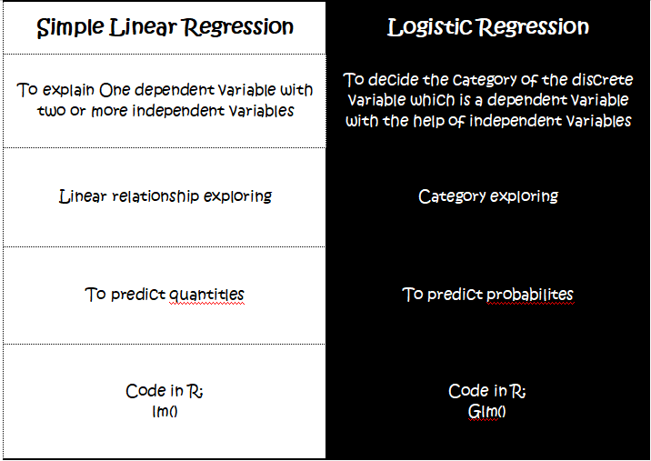

```r
download.file("https://github.com/scizmeli/datascience_class_helper_files/raw/master/psub.RData", "psub.RData")
load("psub.RData")
dtrain <- subset(psub,ORIGRANDGROUP >= 500)
dtest <- subset(psub,ORIGRANDGROUP < 500)
model <- lm(log(PINCP,base=10) ~ AGEP + SEX + COW + SCHL,data=dtrain)
dtest$predLogPINCP <- predict(model,newdata=dtest)
class(dtest$predLogPINCP)# numeric tipinde
```

```
## [1] "numeric"
```

```r
dtrain$predLogPINCP <- predict(model,newdata=dtrain)
```

ORIGRANDGROUP for spliting dataset **COW** : class of Worker

**AGEP** : Age of Person

**SEX** : Sex of Person

**SCHL** : Educational Attainment

**PINCP** :Total person’s income

```r
model <- lm(log(PINCP,base=10) ~ AGEP + SEX + COW + SCHL, data=dtrain)
class(model)# model lm nesnesidir
```

```
## [1] "lm"
```

```r
summary(model)
```

```
##
## Call:
## lm(formula = log(PINCP, base = 10) ~ AGEP + SEX + COW + SCHL,
##     data = dtrain)
##
## Residuals:
##      Min       1Q   Median       3Q      Max
## -1.29220 -0.14153  0.02458  0.17632  0.62532
##
## Coefficients:
##                                     Estimate Std. Error t value Pr(>|t|)
## (Intercept)                         3.973283   0.059343  66.954  < 2e-16 ***
## AGEP                                0.011717   0.001352   8.666  < 2e-16 ***
## SEXF                               -0.093133   0.023405  -3.979 7.80e-05 ***
## COWFederal government employee      0.059727   0.060927   0.980 0.327343
## COWLocal government employee       -0.034417   0.048030  -0.717 0.473928
## COWPrivate not-for-profit employee -0.133524   0.039223  -3.404 0.000709 ***
## COWSelf-employed incorporated      -0.072427   0.068093  -1.064 0.287928
## COWSelf-employed not incorporated  -0.060609   0.069244  -0.875 0.381779
## COWState government employee       -0.081284   0.057796  -1.406 0.160146
## SCHLAssociate's degree              0.221432   0.052094   4.251 2.49e-05 ***
## SCHLBachelor's degree               0.393834   0.043249   9.106  < 2e-16 ***
## SCHLDoctorate degree                0.306554   0.160127   1.914 0.056058 .
## SCHLGED or alternative credential   0.137768   0.078192   1.762 0.078612 .
## SCHLMaster's degree                 0.477284   0.050895   9.378  < 2e-16 ***
## SCHLProfessional degree             0.678774   0.087321   7.773 3.52e-14 ***
## SCHLRegular high school diploma     0.101746   0.042628   2.387 0.017316 *
## SCHLsome college credit, no degree  0.163152   0.042729   3.818 0.000149 ***
## ---
## Signif. codes:  0 '***' 0.001 '**' 0.01 '*' 0.05 '.' 0.1 ' ' 1
##
## Residual standard error: 0.2691 on 578 degrees of freedom
## Multiple R-squared:  0.3383, Adjusted R-squared:  0.3199
## F-statistic: 18.47 on 16 and 578 DF,  p-value: < 2.2e-16
```

```r
# p value <0.05 ten oldugu icin h0 red edilir
# p value >0.05 oldugu icin h0 red edilemez
# yanında *** varsa çok anlamlıdır
# r2 açıklabilrilik yüzdesidir. Bagımsız degiskenlerdeki degisikliklerin bagımslı degiskendeki açıklama basarısıdır
```

# Varsayımlarımızı kontrol etmemizi saglayan grafik turleridir.Grafik lineerligi bozan gözlemleri bize sayısal olarak bize vermektedir

The **Residual vs Fitted plot** is used to detect non-linearity, unequal error variances, and outliers. The **Q-Q plot**, or quantile-quantile plot, is a graphical tool to help us assess if a set of data plausibly came from some theoretical distribution such as a Normal or exponential The **Scale-Location Plot** is how you can check the assumption of equal variance (homoscedasticity). It’s good if you see a horizontal line with equally (randomly) spread points. The **Residuals vs. Leverage plots** helps you identify influential data points on your model. Outliers can be influential

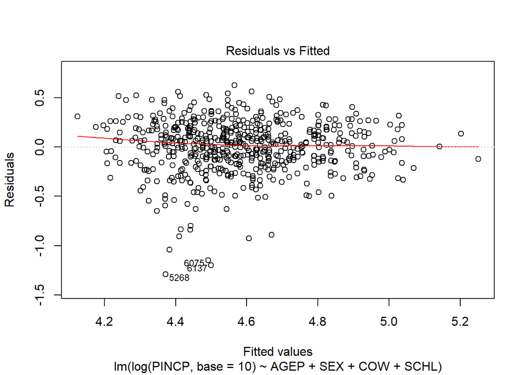

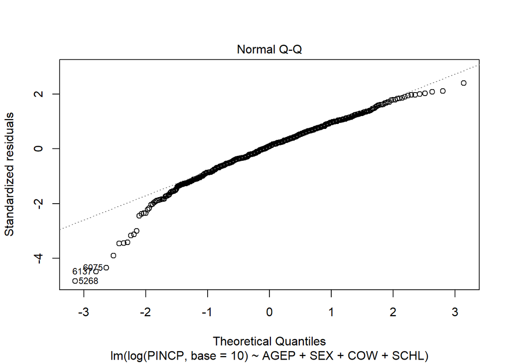

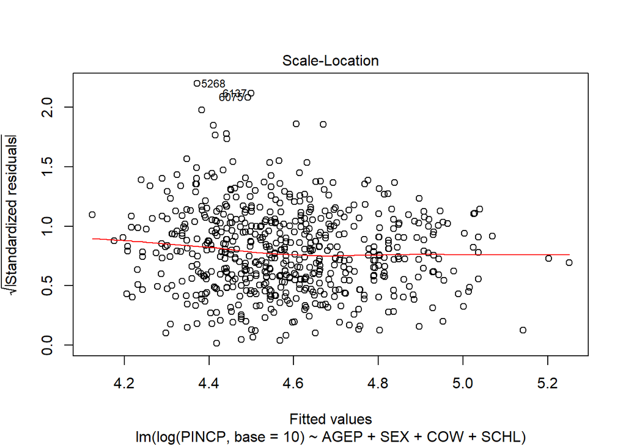

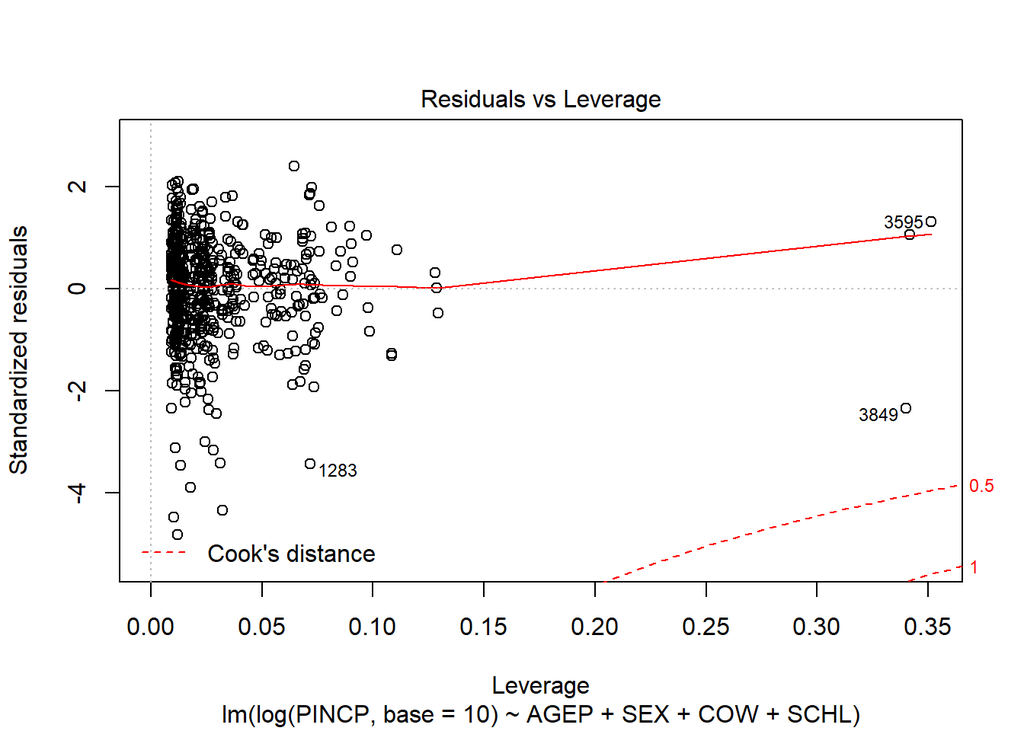

```r
plot(model)
```

```r
#DİKKAT:
# 2.grafik qqplot : normallik varsayımını inceledigimiz grafik
# outlier(uc deger):cok uzakta bir deger varsa ben o degeri farketmediysem .modelimin dogrultusunda cok kucuk yada cok buyuk deger r2 yi büyük olcude etkiler.outlier r2 yi çok etkiler
# aykırı deger: r2 degerini cok fazla etkilemez .
```

```r
dtest$predLogPINCP <- predict(model,newdata=dtest)
```

```r
dtrain$predLogPINCP <- predict(model,newdata=dtrain)
```

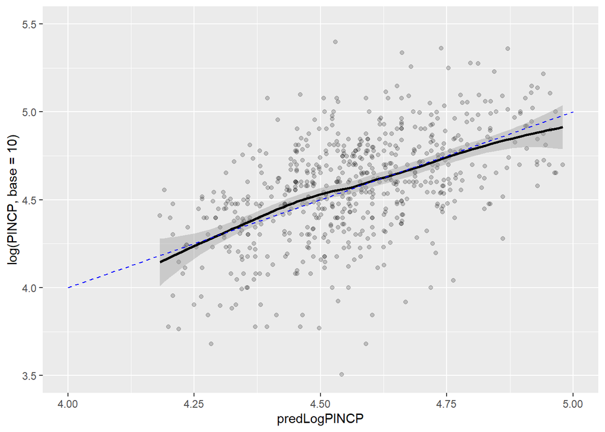

```r
library(ggplot2)
ggplot(data=dtest,aes(x=predLogPINCP,y=log(PINCP,base=10))) +
geom_point(alpha=0.2,color="black") +
geom_smooth(aes(x=predLogPINCP,
y=log(PINCP,base=10)),color="black") +
geom_line(aes(x=log(PINCP,base=10),
y=log(PINCP,base=10)),color="blue",linetype=2) +
scale_x_continuous(limits=c(4,5)) +
scale_y_continuous(limits=c(3.5,5.5))
```

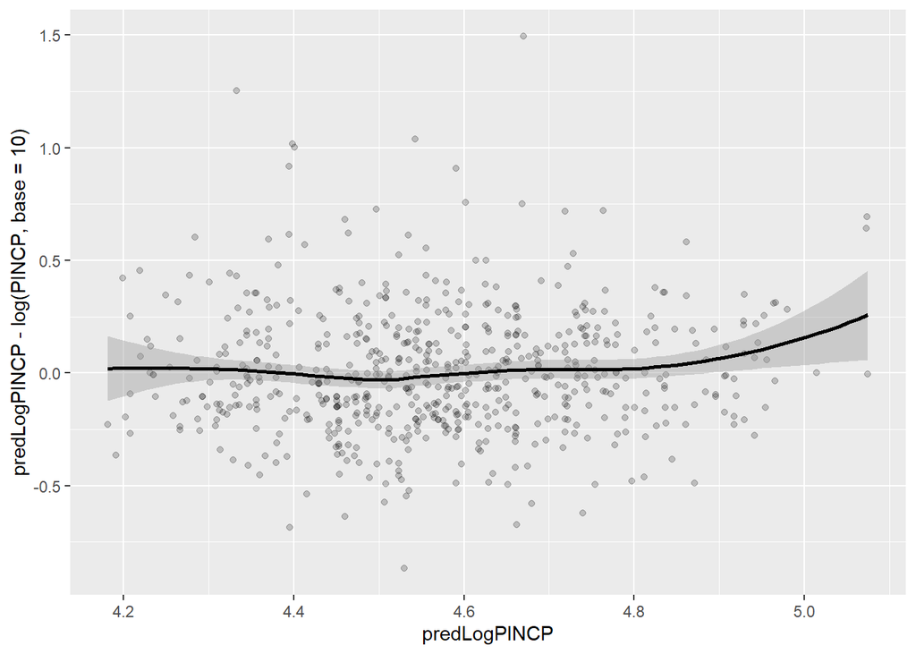

```r
ggplot(data=dtest,aes(x=predLogPINCP,
y=predLogPINCP-log(PINCP,base=10))) +
geom_point(alpha=0.2,color="black") +
geom_smooth(aes(x=predLogPINCP,
y=predLogPINCP-log(PINCP,base=10)),
color="black")
```

```r
#The plot is used to detect non-linearity, unequal error variances, and outliers.
```

```r
coefficients(model)
```

```
##                        (Intercept)                               AGEP
##                         3.97328317                         0.01171695
##                               SEXF     COWFederal government employee
##                        -0.09313262                         0.05972743
##       COWLocal government employee COWPrivate not-for-profit employee
##                        -0.03441690                        -0.13352439
##      COWSelf-employed incorporated  COWSelf-employed not incorporated
##                        -0.07242727                        -0.06060878
##       COWState government employee             SCHLAssociate's degree
##                        -0.08128385                         0.22143196
##              SCHLBachelor's degree               SCHLDoctorate degree
##                         0.39383406                         0.30655376
##  SCHLGED or alternative credential                SCHLMaster's degree
##                         0.13776759                         0.47728422
##            SCHLProfessional degree    SCHLRegular high school diploma
##                         0.67877416                         0.10174598
## SCHLsome college credit, no degree
##                         0.16315219
```

# Logistic Regression

```r
download.file("https://github.com/scizmeli/datascience_class_helper_files/raw/master/NatalRiskData2.RData", "NatalRiskData2.RData")
load("NatalRiskData2.RData")
```

```r
train <- sdata[sdata$ORIGRANDGROUP<=5,]
test <- sdata[sdata$ORIGRANDGROUP>5,]
```

Variable Type Description

**atRisk:** Logical TRUE if 5-minute Apgar score < 7; FALSE otherwise ##logical: true yada false

**PWGT:** Numeric Mother’s prepregnancy weight

**UPREVIS:** Numeric (integer) Number of prenatal medical visits

**CIG_REC:** Logical TRUE if smoker; FALSE otherwise

**GESTREC:** Categorical Two categories: <37 weeks (premature) and >=37 weeks

**DPLURAL:** Categorical Birth plurality, three categories: single/twin/triplet+

**ULD_MECO:** Logical TRUE if moderate/heavy fecal staining of amniotic fluid

**ULD_PRECIP:** Logical TRUE for unusually short labor (< three hours)

**ULD_BREECH:** Logical TRUE for breech (pelvis first) birth position

**URF_DIAB:** Logical TRUE if mother is diabetic

**URF_CHYPER:** Logical TRUE if mother has chronic hypertension

**URF_PHYPER:** Logical TRUE if mother has pregnancy-related hypertension

**URF_ECLAM:** Logical TRUE if mother experienced eclampsia: pregnancyrelated seizures

**Building a logistic regression model**

```r
complications <- c("ULD_MECO","ULD_PRECIP","ULD_BREECH")
riskfactors <- c("URF_DIAB", "URF_CHYPER", "URF_PHYPER",
"URF_ECLAM")
y <- "atRisk"
x <- c("PWGT",
"UPREVIS",
"CIG_REC",
"GESTREC3",
"DPLURAL",
complications,
riskfactors)
fmla <- paste(y, paste(x, collapse="+"), sep="~")
```

```r
print(fmla)
```

```
## [1] "atRisk~PWGT+UPREVIS+CIG_REC+GESTREC3+DPLURAL+ULD_MECO+ULD_PRECIP+ULD_BREECH+URF_DIAB+URF_CHYPER+URF_PHYPER+URF_ECLAM"
```

```r
# glm -logistik regresyon modeli
# glm- generealize lineer model
# sınıflandırma isin kullanılır
model <- glm(fmla, data=train, family=binomial(link="logit"))# argümanlarını girmemiz gerekir
```

This is similar to the linear regression call to lm(), with one additional argument: family=binomial(link=“logit”).

```r
summary(model)
```

```
##
## Call:
## glm(formula = fmla, family = binomial(link = "logit"), data = train)
##
## Deviance Residuals:
##     Min       1Q   Median       3Q      Max
## -0.9732  -0.1818  -0.1511  -0.1358   3.2641
##
## Coefficients:
##                           Estimate Std. Error z value Pr(>|z|)
## (Intercept)              -4.412189   0.289352 -15.249  < 2e-16 ***
## PWGT                      0.003762   0.001487   2.530 0.011417 *
## UPREVIS                  -0.063289   0.015252  -4.150 3.33e-05 ***
## CIG_RECTRUE               0.313169   0.187230   1.673 0.094398 .
## GESTREC3< 37 weeks        1.545183   0.140795  10.975  < 2e-16 ***
## DPLURALtriplet or higher  1.394193   0.498866   2.795 0.005194 **
## DPLURALtwin               0.312319   0.241088   1.295 0.195163
## ULD_MECOTRUE              0.818426   0.235798   3.471 0.000519 ***
## ULD_PRECIPTRUE            0.191720   0.357680   0.536 0.591951
## ULD_BREECHTRUE            0.749237   0.178129   4.206 2.60e-05 ***
## URF_DIABTRUE             -0.346467   0.287514  -1.205 0.228187
## URF_CHYPERTRUE            0.560025   0.389678   1.437 0.150676
## URF_PHYPERTRUE            0.161599   0.250003   0.646 0.518029
## URF_ECLAMTRUE             0.498064   0.776948   0.641 0.521489
## ---
## Signif. codes:  0 '***' 0.001 '**' 0.01 '*' 0.05 '.' 0.1 ' ' 1
##
## (Dispersion parameter for binomial family taken to be 1)
##
##     Null deviance: 2698.7  on 14211  degrees of freedom
## Residual deviance: 2463.0  on 14198  degrees of freedom
## AIC: 2491
##
## Number of Fisher Scoring iterations: 7
```

```r
# logistic regresyonda AIC degerine bakıyoruz
# AIC degeri dusuk olan daha saglam bir modeldir diyoruz.
# Logistic regresyonda yorumlama yaparken bir birimlik artıs oldugunda y de bir birimlik artıs oluyo diye yorum yapamayız. odds degerine bakmalıyız.
# veri setine baktıgımızda annenin sigara icmesindeki bir birimlik artıs bebegin riske girme oranı artar diye bir yorum yapılamaz.
```

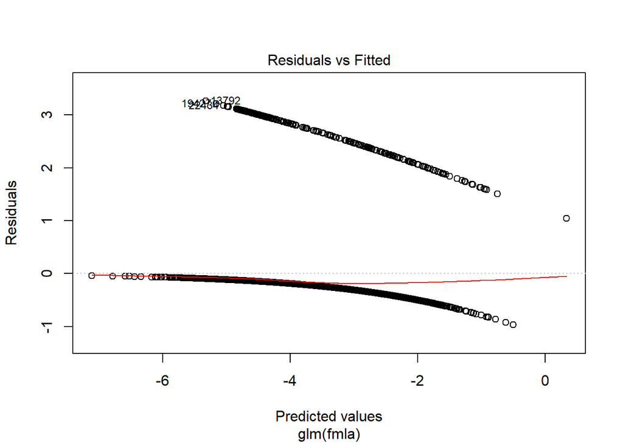

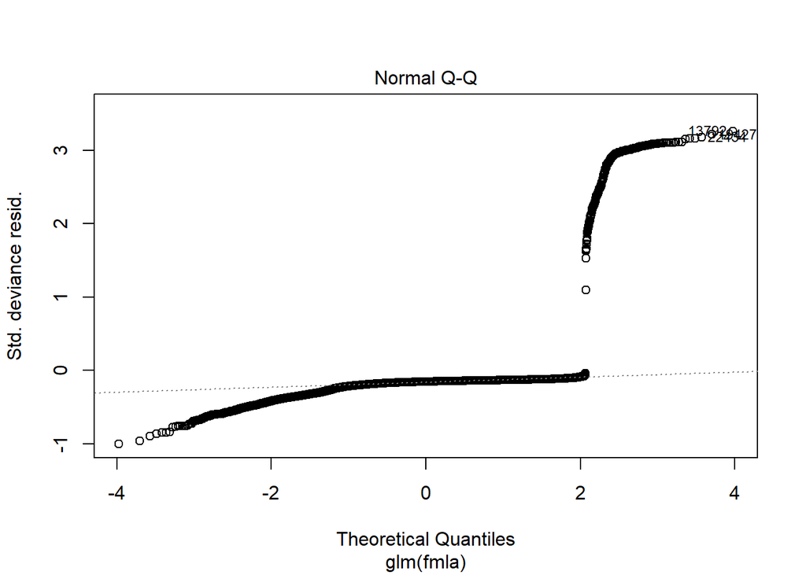

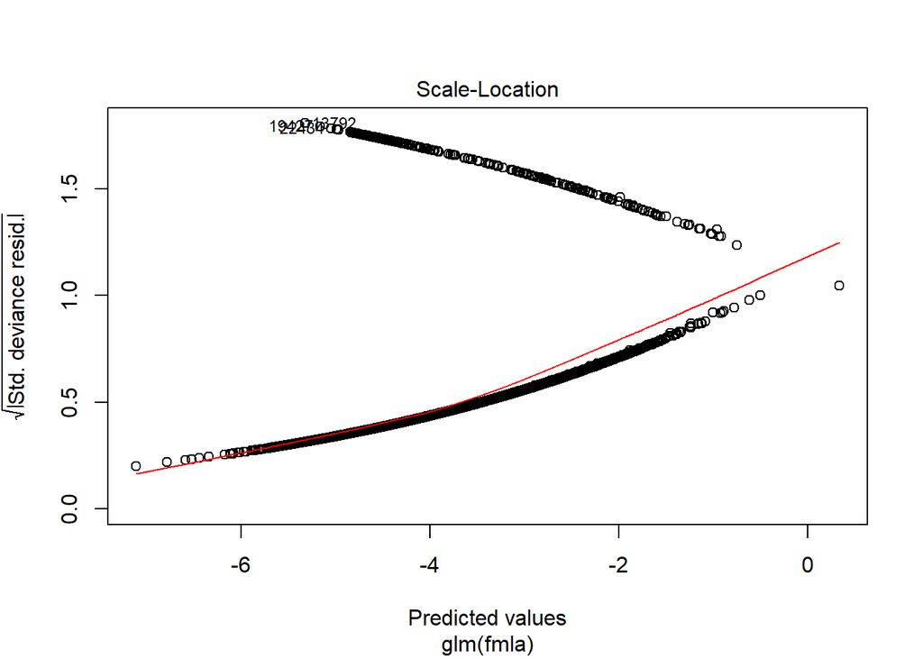

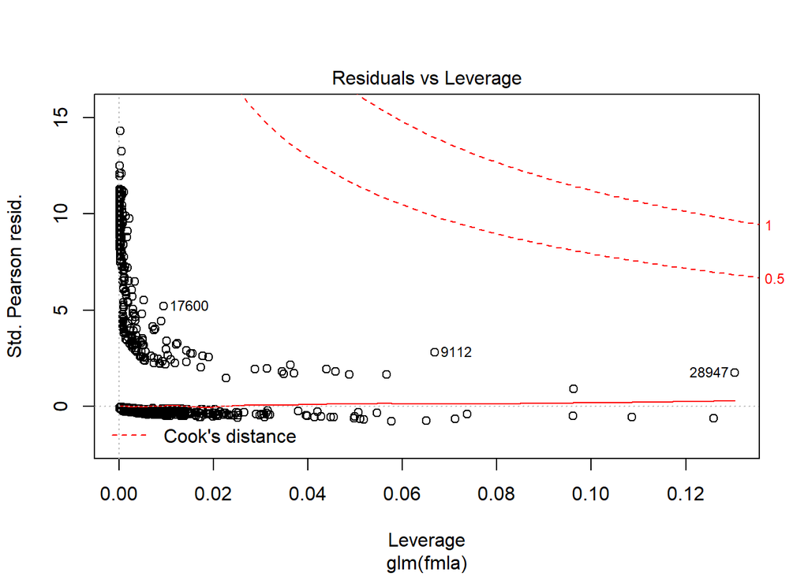

```r
plot(model)
```

Applying the logistic regression model Making Prediction

```r
train$pred <- predict(model, newdata=train, type="response")
test$pred <- predict(model, newdata=test, type="response")
```

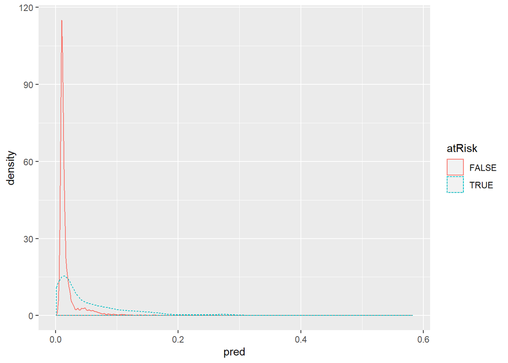

```r
library(ggplot2)
ggplot(train, aes(x=pred, color=atRisk, linetype=atRisk)) +
geom_density()
```

Distribution of score broken up by positive examples (TRUE) and negative examples (FALSE) **The model coefficients**

```r
coefficients(model)
```

```
##              (Intercept)                     PWGT                  UPREVIS
##              -4.41218940               0.00376166              -0.06328943
##              CIG_RECTRUE       GESTREC3< 37 weeks DPLURALtriplet or higher
##               0.31316930               1.54518311               1.39419294
##              DPLURALtwin             ULD_MECOTRUE           ULD_PRECIPTRUE
##               0.31231871               0.81842627               0.19172008
##           ULD_BREECHTRUE             URF_DIABTRUE           URF_CHYPERTRUE
##               0.74923672              -0.34646672               0.56002503
##           URF_PHYPERTRUE            URF_ECLAMTRUE
##               0.16159872               0.49806435
```

**Lets About Talking** What is the mean of these coefficients? Let’s discuss What is the mean of these AIC? Let’s discuss